# Untitled

2022-10-24

## Introduction

近年来，基于退化的可靠性技术在模型、方法和应用等方面得到快速发展。其中，在**基于退化的可靠性模型**方面，以随机过程理论为基础，根据工程需要，并考虑模型的简明性、实用性和适用性，已经提出了多种类型的模型，包括：

1. 退化轨道模型（如 Paris 模型、随机斜率/截距模型、幂律模型、反应论模型）
2. 基于 Wiener 过程的模型
3. 基于 Gamma 过程的模型
4. 累积损伤模型(主要是基于混合 Poisson 过程的模型）
5. 更为一般的纯跳过程模型（如Levy.过程模利）和扩散过程模型（如随机微分方程模型）等。

在基于退化的可靠性建模方法，以数理统计理论为基础，针对模型和退化数据的类型，研究**矩估计、极大似估计及 EM 算法、Bayes 估计及 MCMC算法、基于滤波的状态估计方法**，以及**非参数和半参数方法**等，解决模型辨识和修正问题;

采用**似然比检验、Bayes 因子分析**等方法进行模型验证;

采用**均方误差（MSE）、Akaike 信息准则(AIC)、Bayes 信息准则(BIC)、偏差信息准则(DIC)**等进行模型优良性检验。

在基于退化的可靠性技术应用方面，针对**机械零部件（如轴承、润滑系统）、半导体器件（如功率MOS器件）、机电部件（如感应电动机）、光电器件(如太阳电池、激光器、LED)、电子器件（如电容、蓄电池）**等的退化失效过程，开展**退化过程建模、可靠性评估、剩余寿命预测、可靠性试验设计**：特别是加速退化试验方案设计的研究。

## Wiener 退化过程模型

Wiener 过程由于其简单的结构和比较丰富的研究成果，成为目前退化过程建模中 应用最为广泛的一种模型。

Wiener 退化过程的**首达时间分布具有解析形式**，便于对**产品寿命**和**可靠度**的分析和计算。

Wiener 退化过程可以描述产品退化过程的时间不确定性，而且比较容易处理测量数据存在误差的情况。

通过对经典 Wiener 过程的参数引入**随机性**，使得 Wiener 退化过程能够描述个体差异，并且一般不会给模型参数的估计带来更多的困难。

对 Wiener 退化过程及其观测过程所构成的**状态空间模型**，可以采用 **Kalman 滤波技术**进行处理，为产品**在线寿命预测、视情维修决策**等提供了可行的算法和实现途径。

```r
library(ggplot2)
library(tidyverse)
library(viridis)
library(dplyr)
```

### 数据模拟产生

```r
# 数据模拟产生
sim_dat = function(group = 6, t = 1:200, para = c(1,0.1)){
  # para 指 mu,sigma
  # epoch 指测量次数， group 指组数
  delta_t = diff(t)
  epoch = length(delta_t)
  dat = matrix(NA,epoch,group+1)
  dat[,1] = seq(1,epoch)
  dat_unit = numeric()
  for(i in 1:group){
    for(j in 1:epoch) dat_unit[j] = rnorm(1,para[1]*delta_t[j],sqrt(para[2]^2*delta_t[j]))
    dat[,i+1] = cumsum(dat_unit)
  }
  dat = data.frame(dat)
  dat1 = rbind(rep(0,group+1),dat) # 加入初始值绘制点
  colnames(dat1) = c("Time",paste(1:group,sep=''))
  return(dat1)
}
```

#### 绘制退化路径图

```r
# 绘制退化路径图
plot_path = function(data = dat1){
    # 画图
  p = data %>% pivot_longer(paste(1:group),
                       names_to = "Group",
                       values_to = "y") %>%
    ggplot(aes(Time,y,color = Group)) +
    geom_line() +
    scale_color_viridis(discrete = T) +
    ylab("Degradation") #+
    #theme_bw() +
    #theme(panel.grid = element_blank())
  print(p)
}
```

```r
group = 6
t = 1:200
para = c(1,1)
dat = sim_dat(group = group, t = t, para = para)
knitr::kable(head(dat))
```

| Time | 1 | 2 | 3 | 4 | 5 | 6 |
| --- | --- | --- | --- | --- | --- | --- |
| 0 | 0.000000 | 0.0000000 | 0.0000000 | 0.000000 | 0.0000000 | 0.000000 |
| 1 | 2.261986 | 0.8749848 | 1.0250508 | 1.049642 | -0.1883638 | 2.248283 |
| 2 | 3.388003 | 2.6947802 | 0.9322305 | 3.557694 | -0.6143240 | 3.574578 |
| 3 | 2.945683 | 4.7444336 | 1.9980681 | 4.407076 | 0.7074874 | 4.176640 |
| 4 | 2.756832 | 5.8958285 | 1.4792307 | 6.647330 | 2.9790348 | 6.341555 |
| 5 | 4.602088 | 7.8075543 | 3.3984997 | 5.595758 | 4.1136127 | 7.724431 |

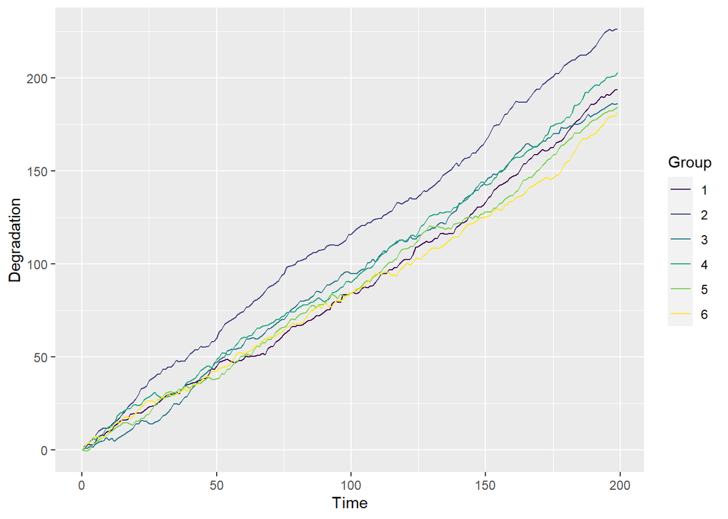

```r
plot_path(dat)
```

### 参数估计

#### 极大似然估计

```r
cumsub = function(x){
  #逐个相减
  re = numeric()
  re[1] = x[1]
  for(i in 2:length(x)){
    re[i] = x[i] - x[i-1]
  }
  return(re)
}
```

```r
Weiner_mle = function(par = c(1,1),data = dat){
  mu = par[1]; sigma = par[2]
  group = ncol(data) - 1;time = data[,1];y = data[-1,-1]
  # 差分得到delta_time和delta_y
  delta_time = matrix(rep(diff(time),group),length(diff(time)),group)
  delta_y = matrix(NA,nrow(delta_time),group)
  for(i in 1:group) delta_y[,i] = cumsub(y[,i])

  logl = -1/2 * sum(log(delta_time)) - group*nrow(delta_time)*log(sigma) - sum((delta_y - mu * delta_time)^2/(2*sigma^2*delta_time),na.rm =T)

  return(-logl)
}

mle_re = optim(par=c(1,1), fn = Weiner_mle,
      data = dat, method = "BFGS", hessian = TRUE)
mle_re
```

```
## $par
## [1] 0.9834798 1.0008319
##
## $value
## [1] 597.9932
##
## $counts
## function gradient
##       22        5
##
## $convergence
## [1] 0
##
## $message
## NULL
##
## $hessian
##               [,1]          [,2]
## [1,]  1.192016e+03 -8.693775e-04
## [2,] -8.693775e-04  2.384055e+03
```

```r
mle_par = mle_re$par
```

```r
## 可靠度计算
Wiener_R = function(t = 100, threshold = 150,par = mle_par){
  R = pnorm((threshold - par[1]*t)/(par[2]*sqrt(t))) - exp(2*par[1]*threshold/par[2]) * pnorm((-threshold - par[1]*t)/(par[2]*sqrt(t)))
  return(R)
}
Wiener_R(t = 100, threshold = 150,par = mle_par)
```

```
## [1] 0.9999998
```

```r
# plot(Wiener_R(t = 1:300, threshold = 150,par = mle_par),type = "l")
```

#### 案例分析

导入数据，数据来源于[NASA Ames Prognostics Center of Excellence (PCoE)](https://c3.ndc.nasa.gov/dashlink/resources/133/)，但是找不到数据下载。最后是通过 [Github](https://github.com/psanabriaUC/BatteryDatasetImplementation) 获得。

```r
liion_data = read.csv("dataset/li-ion_battery_aging.csv")
head(liion_data)
```

```
##   Voltage_measured Current_measured Temperature_measured Current_charge
## 1         3.974871        -2.012528             24.38909         1.9982
## 2         3.951717        -2.013979             24.54475         1.9982
## 3         3.934352        -2.011144             24.73139         1.9982
## 4         3.920058        -2.013007             24.90982         1.9982
## 5         3.907904        -2.014400             25.10588         1.9982
## 6         3.897036        -2.011603             25.31702         1.9982
##   Voltage_charge    Time Capacity id_cycle      type ambient_temperature time
## 1          3.062  35.703 1.856487        1 discharge                  24 2008
## 2          3.030  53.781 1.856487        1 discharge                  24 2008
## 3          3.011  71.922 1.856487        1 discharge                  24 2008
## 4          2.991  90.094 1.856487        1 discharge                  24 2008
## 5          2.977 108.281 1.856487        1 discharge                  24 2008
## 6          2.967 126.453 1.856487        1 discharge                  24 2008
##   Battery
## 1   B0005
## 2   B0005
## 3   B0005
## 4   B0005
## 5   B0005
## 6   B0005
```

该数据是 NASA Ames Prognostics Center of Fxcellence (PCoF）对商用锂离子 18650 电池进行充、放电试验获得的一组蓄电池容量变化数据。试验过程中，锂离子在室温下 经历 3 种不同的运行剖面，即**充电**、**放电**和**测量 EIS**。

充电是以**恒流模**式(CC)进行，在 1.5A 电流下直到电池电压达到4.2V，然后以**恒压模式**(CV)继续充电直到电流降到 20mA。

放电也以恒流模式进行，放电电流为2A，直到电池电压降低到2.7V。

重复充电和放电降导致蓄电池老化。对应的四个产品电池容量变化如下图所示：

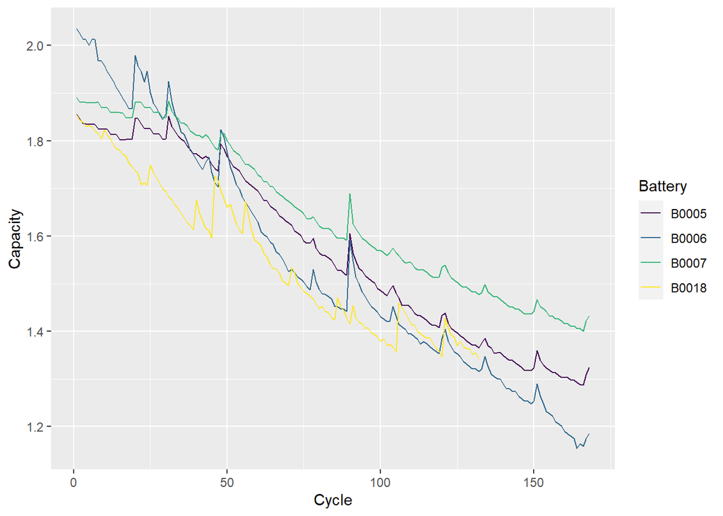

```r
liion_data %>%
  ggplot(aes(id_cycle,Capacity,color = Battery)) +
  geom_line() +
  scale_color_viridis(discrete = T) +
  xlab("Cycle") #+
```

```r
  #theme_bw() + theme(panel.grid = element_blank())
```

我们直接使用充放电循环次数作为时间刻度。由于随着时间的推移，电池容量呈下降趋势。而用维纳过程来进行 RUL 预测方法是建立在退化过程有增加趋势的基础上的。为了应用该模型，对原始数据进行转换：用初始容量减去每个电池的所有容量数据。此时，失效阈值更改为初始容量减去 1.4 Ahr。

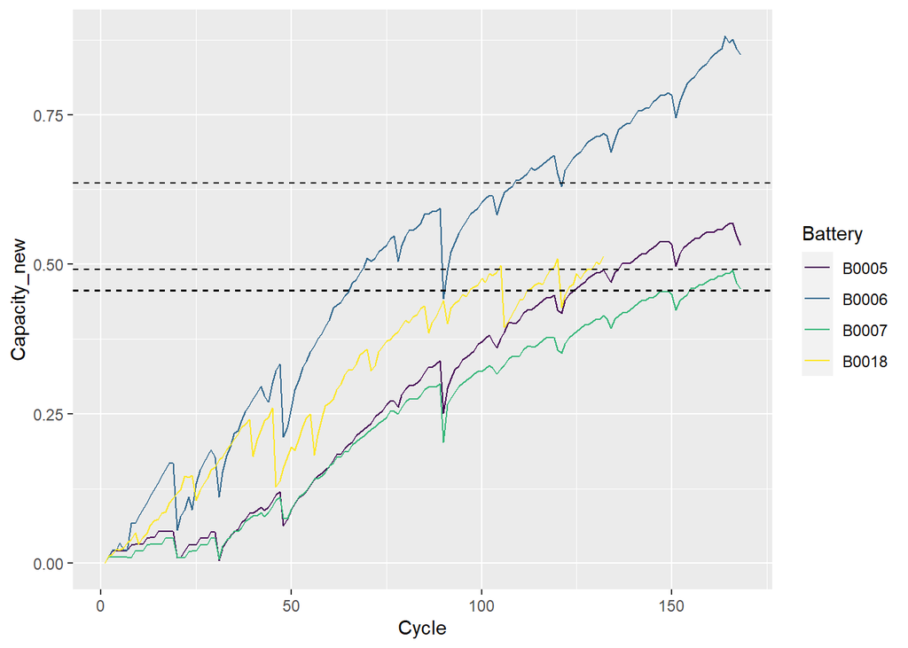

```r
max_battery = aggregate(liion_data$Capacity,by = list(liion_data$Battery),max)
max_battery$threshold = max_battery$x - 1.4

liion_data$Capacity_new = -liion_data$Capacity + rep(max_battery[,2],as.numeric(table(liion_data$Battery)))

liion_data %>%
  ggplot(aes(id_cycle,Capacity_new,color = Battery)) +
  geom_line() +
  scale_color_viridis(discrete = T) +
  xlab("Cycle") +
  #theme_bw() +
  #theme(panel.grid = element_blank()) + #添加失效阈值
  geom_hline(yintercept = max_battery$threshold[1],lty = 2) +
    geom_hline(yintercept = max_battery$threshold[2],lty = 2) +
      geom_hline(yintercept = max_battery$threshold[3],lty = 2) +
      geom_hline(yintercept = max_battery$threshold[4],lty = 2)
```

前面对数据进行了导入、处理以及可视化。接下来，使用经典的线性维纳过程对其进行建模。

```r
liion_data %>%
  select(Capacity_new,Battery,id_cycle) %>%
  pivot_wider(
    names_from = "Battery",
    values_from = "Capacity_new",
    values_fn = mean) -> liion_new
```

```r
mle_re = optim(par=c(1,1), fn = Weiner_mle,
      data = data.frame(liion_new), method = "BFGS", hessian = TRUE)
mle_par = mle_re$par
mle_par
```

```
## [1] 0.003751909 0.017612386
```

计算可靠度并绘图

```r
# 计算可靠度
Wiener_R(t = 100, threshold = max_battery$threshold, par = mle_par)
```

```
## [1] 0.6778098 0.9301711 0.7446791 0.6747844
```

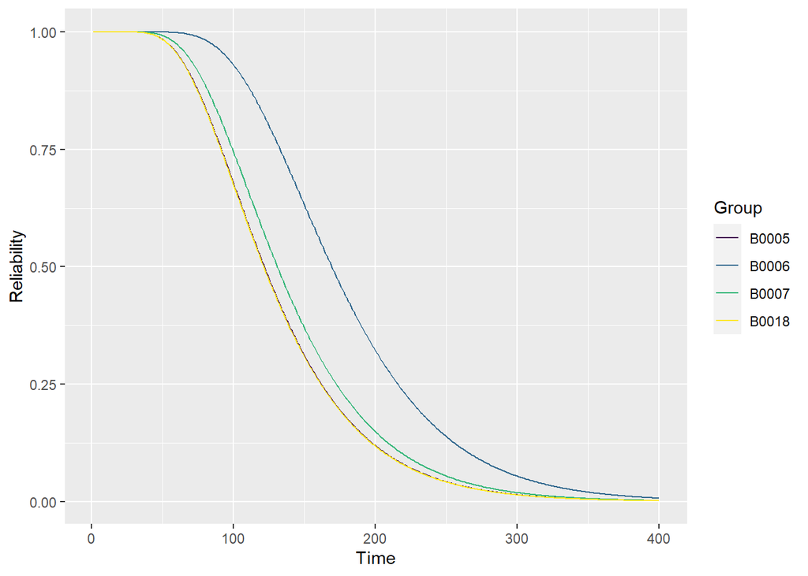

```r
time_region = 400
# 绘制四个电池的可靠度图
R_re = matrix(NA,time_region,4)
for(i in 1:4){
  R_re[,i] = Wiener_R(t = 1:time_region, threshold = max_battery$threshold[i],par = mle_par)
}
R_re = as.data.frame(R_re)
R_re = cbind(1:time_region,R_re)
colnames(R_re) = c("time",max_battery[,1])
R_re %>% pivot_longer(max_battery[,1],
                       names_to = "Group",
                       values_to = "y") %>%
  ggplot(aes(time,y,color = Group,shape = Group)) +
  geom_line() +
  scale_color_viridis(discrete = T) +
  labs(x = "Time", y = "Reliability")
```